# mFD: General Workflow

Camille Magneville

2024-02-26

# About this tutorial

This tutorial describes the basic workflow showing how to compute step by step functional diversity (FD) indices in a multidimensional space using `mFD` package. Other functions are available and their uses are illustrated in others tutorials.

**DATA** The dataset used to illustrate this tutorial is a **fruits dataset** based on 25 types of fruits (*i.e.* species) distributed in 10 fruits baskets (*i.e.* assemblages). Each fruit is characterized by five traits values summarized in the following table:

| Trait name | Trait measurement | Trait type | Number of classes | Classes code | Unit |
| --- | --- | --- | --- | --- | --- |
| Size | Maximal diameter | Ordinal | 5 | 0-1 ; 1-3 ; 3-5 ; 5-10 ; 10-20 | cm |
| Plant | Growth form | Categorical | 4 | tree; shrub; vine; forb | NA |
| Climate | Climatic niche | Ordinal | 3 | temperate ; subtropical ; tropical | NA |
| Seed | Seed type | Ordinal | 3 | none ; pip ; pit | NA |
| Sugar | Sugar | Continuous | NA | NA | g/kg |

# Overview of the functional framework

The use of the `mFD` package is based on two datasets:

- a **data frame** summarizing traits values for each species called `fruits_traits` in this tutorial

```r
# Load data:
data("fruits_traits", package = "mFD")

# Remove fuzzy traits in this tutorial:
fruits_traits <- fruits_traits[ , -c(6:8)]

# Display the table:
knitr::kable(head(fruits_traits),
             caption = "Species x traits data frame")
```

Species x traits data frame

|  | Size | Plant | Climate | Seed | Sugar |
| --- | --- | --- | --- | --- | --- |
| apple | 5-10cm | tree | temperate | pip | 103.9 |
| apricot | 3-5cm | tree | temperate | pit | 92.4 |
| banana | 10-20cm | tree | tropical | none | 122.3 |
| currant | 0-1cm | shrub | temperate | pip | 73.7 |
| blackberry | 1-3cm | shrub | temperate | pip | 48.8 |
| blueberry | 0-1cm | forb | temperate | pip | 100.0 |

- a **matrix** summarizing species assemblages called `baskets_fruits_weights` in this tutorial. Weights in this matrix can be occurrence data, abundance, biomass, coverage, etc. This matrix must have assemblages names in rownames. The studied example works with biomass (*i.e.* grams of a fruit in a basket) and this matrix looks as follows:

```r
# Load data:
data("baskets_fruits_weights", package = "mFD")

# Display the table:
knitr::kable(as.data.frame(baskets_fruits_weights[1:6, 1:6]),
      centering = TRUE,
      caption = "Species x assemblages matrix based on the **fruits** dataset")
```

Species x assemblages matrix based on the **fruits** dataset

|  | apple | apricot | banana | currant | blackberry | blueberry |
| --- | --- | --- | --- | --- | --- | --- |
| basket_1 | 400 | 0 | 100 | 0 | 0 | 0 |
| basket_2 | 200 | 0 | 400 | 0 | 0 | 0 |
| basket_3 | 200 | 0 | 500 | 0 | 0 | 0 |
| basket_4 | 300 | 0 | 0 | 0 | 0 | 0 |
| basket_5 | 200 | 0 | 0 | 0 | 0 | 0 |
| basket_6 | 100 | 0 | 200 | 0 | 0 | 0 |

This tutorial will guide you through the main framework, illustrated in the flowchart below, step by step.

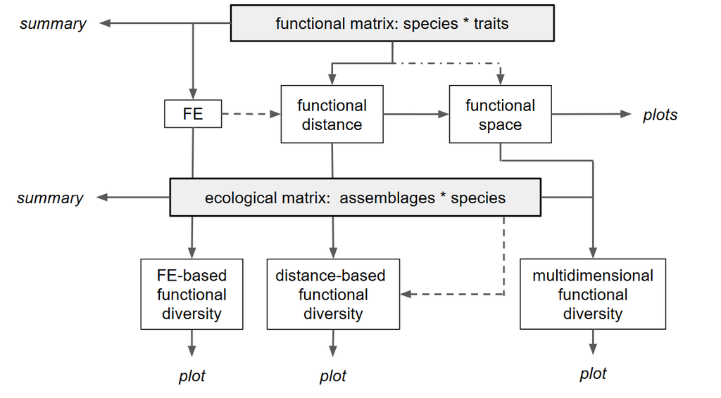

Basic framework of the mFD package

# 1. Know your data

## 1.1. What types of traits am I using?

The first thing to do before starting analyses is to know your data. To do so, you must be able to characterize the traits you are using (*i.e.* tell the package what type of traits you are using). That is why `mFD` package needs a data frame summarizing the type of each trait (*i.e.* each column of the `fruits_traits` data frame).

**NB** You need to set up a data frame with the same columns names as the below example and traits names need to be in the same order as in the `fruits_traits` data frame:

```r
# Load data:
data("fruits_traits_cat", package = "mFD")

# Remove fuzzy traits in this tutorial:
fruits_traits_cat <- fruits_traits_cat[-c(6:8), ]
# Thus remove the "fuzzy_name" column:
fruits_traits_cat <- fruits_traits_cat[ , -3]

# Display the table:
knitr::kable(head(fruits_traits_cat),
             caption = "Traits types based on **fruits & baskets** dataset")
```

Traits types based on **fruits & baskets** dataset

| trait_name | trait_type |
| --- | --- |
| Size | O |
| Plant | N |
| Climate | O |
| Seed | O |
| Sugar | Q |

The **first column** contains **traits name**. The **second column** contains **traits type** following this code:

- **N**: nominal trait (factor variable)
- **O**: ordinal traits (ordered variable)
- **C**: circular traits (integer values) (**NB** circular traits can not be used in `mFD` function used to compute functional distance but ok for summary function and function to group species into Functional Entities)
- **Q**: quantitative traits (numeric values)
- **F**: fuzzy traits (described with several values defined in several columns in the `fruits_traits` data frame)

You can add a **third column** **if** your dataset use fuzzy traits (then the third column summarizes to which fuzzy trait belongs each column that refers to a fuzzy trait) **or if** you want to give weight to each traits (then the third column summarizes traits weights).

**NOTE** The traits types dataframe thus has: **two columns** if **no fuzzy traits and no weight given to traits** (columns names: `trait_name` and `trait_type`) ; **three columns** if **fuzzy traits** (columns names: `trait_name`,`trait_type` and `fuzzy_name`) **or** if **no fuzzy traits and weight given to traits** (columns names: `trait_name`,`trait_type` and `trait_weight`). See the first part of the [Compute Functional Diversity Hill Indices](https://cmlmagneville.github.io/mFD/articles/Compute_functional_hill_indices.html) to see how the `fruits_traits` and `fruits_traits_cat` look like with fuzzy traits.

## 1.2. Summarize my traits

The `mFD` package helps you to **summarize your data** using two distinct functions: `mFD::sp.tr.summary()` and `mFD::asb.sp.summary()`.

The function `mFD::sp.tr.summary()` summarizes the `fruits_traits` dataframe and returns a list gathering several tables and lists:

- tables with summaries for non-fuzzy & fuzzy traits. **For non-fuzzy traits**, the table sums up the number of species having each category for ordinal, nominal and circular traits or minimum/first quartile/median/mean/third quartile/maximum for continuous traits. **For fuzzy traits**, the table sums up minimum/first quartile/median/mean/third quartile/maximum for each category of each fuzzy trait.
- a list gathering traits types for non-fuzzy traits
- a list gathering modalities of non-continuous and non-fuzzy traits

**USAGE**

```r
# Species traits summary:
fruits_traits_summ <- mFD::sp.tr.summary(
  tr_cat     = fruits_traits_cat,
  sp_tr      = fruits_traits,
  stop_if_NA = TRUE)
```

```r
fruits_traits_summ$"tr_types"                     # Traits types
```

```
## $Size
## [1] "ordered" "factor"
##
## $Plant
## [1] "factor"
##
## $Climate
## [1] "ordered" "factor"
##
## $Seed
## [1] "ordered" "factor"
##
## $Sugar
## [1] "numeric"
```

```r
fruits_traits_summ$"mod_list"                     # Traits types for non-continuous and non-fuzzy traits
```

```
## $Size
## [1] 5-10cm  3-5cm   10-20cm 0-1cm   1-3cm
## Levels: 0-1cm < 1-3cm < 3-5cm < 5-10cm < 10-20cm
##
## $Plant
## [1] tree  shrub forb  vine
## Levels: forb shrub tree vine
##
## $Climate
## [1] temperate   tropical    subtropical
## Levels: temperate < subtropical < tropical
##
## $Seed
## [1] pip  pit  none
## Levels: none < pip < pit
##
## $Sugar
##  [1] 103.9  92.4 122.3  73.7  48.8 100.0 128.2 162.5  73.1  89.9  25.0  16.9
## [13] 152.3 136.6  78.6  91.4 112.0  83.9  97.5  98.5  99.2  44.0  48.9 105.8
## [25]  81.2
```

## 1.3. Summarize my assemblages

The second function helping you to summarize your data in the `mFD` package is `mFD::asb.sp.summary()`. It summarizes the `baskets_fruits_weights` matrix and returns a list gathering a matrix, a list and several vectors:

- a matrix of species occurrences
- a vector gathering species total biomass in all assemblages
- a vector gathering the total abundance/biomass per assemblage
- a vector gathering species richness per assemblage
- a list gathering species names present in each assemblage

**USAGE**

```r
# Summary of the assemblages * species dataframe:
asb_sp_fruits_summ <- mFD::asb.sp.summary(asb_sp_w = baskets_fruits_weights)
```

```r
head(asb_sp_fruits_summ$"asb_sp_occ", 3)        # Species occurrences for the first 3 assemblages
```

```
##          apple apricot banana currant blackberry blueberry cherry grape
## basket_1     1       0      1       0          0         0      1     0
## basket_2     1       0      1       0          0         0      1     0
## basket_3     1       0      1       0          0         0      1     0
##          grapefruit kiwifruit lemon lime litchi mango melon orange
## basket_1          0         0     1    0      0     0     1      0
## basket_2          0         0     1    0      0     0     1      0
## basket_3          0         0     1    0      0     0     1      0
##          passion_fruit peach pear pineapple plum raspberry strawberry tangerine
## basket_1             1     0    1         0    0         0          1         0
## basket_2             1     0    1         0    0         0          1         0
## basket_3             1     0    1         0    0         0          1         0
##          water_melon
## basket_1           0
## basket_2           0
## basket_3           0
```

```r
asb_sp_fruits_occ <- asb_sp_fruits_summ$"asb_sp_occ"
```

```r
asb_sp_fruits_summ$"sp_tot_w"              # Species total biomass in all assemblages
```

```
##         apple       apricot        banana       currant    blackberry
##          1850           200          1400           300           400
##     blueberry        cherry         grape    grapefruit     kiwifruit
##           300           950           900           300           400
##         lemon          lime        litchi         mango         melon
##          1200           400           300           700          1500
##        orange passion_fruit         peach          pear     pineapple
##           900           300           600          1900          1000
##          plum     raspberry    strawberry     tangerine   water_melon
##           550           900          1650           300           800
```

```r
asb_sp_fruits_summ$"asb_tot_w"             # Total biomass per assemblage
```

```
##  basket_1  basket_2  basket_3  basket_4  basket_5  basket_6  basket_7  basket_8
##      2000      2000      2000      2000      2000      2000      2000      2000
##  basket_9 basket_10
##      2000      2000
```

```r
asb_sp_fruits_summ$"asb_sp_richn"           # Species richness per assemblage
```

```
##  basket_1  basket_2  basket_3  basket_4  basket_5  basket_6  basket_7  basket_8
##         8         8         8         8         8         8         8         8
##  basket_9 basket_10
##         8         8
```

```r
asb_sp_fruits_summ$"asb_sp_nm"[[1]]             # Names of species present in the first assemblage
```

```
##         apple        banana        cherry         lemon         melon
##             1             1             1             1             1
## passion_fruit          pear    strawberry
##             1             1             1
```

# 2. Gathering species into functional entities

If you have many species described by few categorical and ordinal traits only, then you might want to group them into Functional Entities (**FE**), *i.e* **groups of species with same trait values when species are described with categorical and/or ordinal traits**. It is particularly useful when using large datasets with “functionally similar” species.

In this tutorial, this function is not illustrated (FE for the **fruits** dataset have a single species) and thus functional diversity indices based on FE are not computed. You can have a look to the [Compute Functional Diversity Indices based on Functional Entities](https://cmlmagneville.github.io/mFD/articles/How_to_deal_with_Functional_Entities.html) tutorial for further analysis using FE.

`mFD` also allows the user to compute FD indices based on Functional Entities (FEs). Computed indices are **Functional Redundancy (FRed)**, **Functional OverRedundancy (FORed)** and **Functional Vulnerability (FVuln)** ([Mouillot *et al.* 2014](https://www.pnas.org/doi/abs/10.1073/pnas.1317625111)). The **fruits & baskets** example does not allow to compute FEs, thus FD indices based on FEs can not be compute. Check the [Compute functional diversity indices based on Functional Entities](https://cmlmagneville.github.io/mFD/articles/How_to_deal_with_Functional_Entities.html) tutorial to see how to compute them.

# 3. Computing distances between species based on functional traits

The next step toward the computation of functional diversity indices is to estimate functional traits-based distances between species in order to build the functional space in which indices will be computed.

To compute trait-based distances, we will use the `mFD::funct.dist()` function which includes the following arguments:

**USAGE**

```r
sp_dist_fruits <- mFD::funct.dist(
  sp_tr         = fruits_traits,
  tr_cat        = fruits_traits_cat,
  metric        = "gower",
  scale_euclid  = "scale_center",
  ordinal_var   = "classic",
  weight_type   = "equal",
  stop_if_NA    = TRUE)
```

- `sp_tr` is the species x trait data frame
- `tr_cat` is the data frame summarizing trait type for each trait
- `metric` is a character string referring to the metric used to compute distances. Two metrics are available and **the choice depends on your traits data**:
  - if **all traits are continuous** use the **Euclidean distance** (`metric = "euclidean"`) and check the [Compute Functional Diversity Indices based on Only Continuous Traits](https://cmlmagneville.github.io/mFD/articles/Continuous_traits_framework.html) tutorial which explains how to build a multidimensional space from traits through PCA analysis or considering directly each trait as a dimension.
  - if you have **non-continuous traits** use the **Gower distance** (`metric = "gower"`) as this method allows traits weighting. This method can also deal with fuzzy traits.
- `scale_euclid` is a character string referring to the way the user wants to scale **euclidean** traits. You can either chose to scale by range `range`, use the center transformation `center`, use the scale transformation `scale`, use the scale-center transformation `scale_center` or you can chose not to scale `noscale`.
- `ordinal_var` is a character string specifying the method to be used for ordinal variables (*i.e.* ordered). You can either chose to treat ordinal variables as continuous variables (with `"classic"` option) or to treat ordinal variables as ranks (with `metric` or `podani` options, see `mFD::funct.dist()` help file for details).
- `weight_type` is a character string referring to the type of method to weight traits. You can either chose to define weights using the `tr_cat` dataframe (cf **step 1.1**) (`user` option) or you can chose to give the same weight to all traits (`equal` option). (**NB** Using `mFD`, you can not define weights for fuzzy traits, use [`gawdis`](https://cran.r-project.org/package=gawdis) package instead) (**NB** If you only have continuous traits (see the [Continuous traits Framework](https://cmlmagneville.github.io/mFD/articles/Continuous_traits_framework.html): using up to the 1.0.6.9 version of the `mFD` package does not allow weighting, it will be done in a next version of the package. You can use the [`col.w`](https://rdrr.io/cran/FactoMineR/man/PCA.html) argument of the PCA function of the FactomineR package.)
- `stop_if_NA` is a logical value to stop or not the process if the `sp_tr` data frame contains NA. If the `sp_tr` data frame contains `NA` you can either chose to compute anyway functional distances (but keep in mind that **Functional measures are sensitive to missing traits!**) or you can delete species with missing or extrapolate missing traits (see [Johnson *et al.* (2020)](https://onlinelibrary.wiley.com/doi/full/10.1111/geb.13185)).

**NB** **If your data gather a high number of species and/or traits, this function might take time to run (and you might have memory issues).**

This function returns a `dist` object with traits-based distances between all pairs of species:

```r
round(sp_dist_fruits, 3)                 # Output of the function mFD::funct.dist()
```

```
##               apple apricot banana currant blackberry blueberry cherry grape
## apricot       0.166
## banana        0.375   0.541
## currant       0.391   0.426  0.767
## blackberry    0.376   0.410  0.751   0.084
## blueberry     0.355   0.410  0.731   0.236      0.320
## cherry        0.233   0.099  0.558   0.425      0.409     0.389
## grape         0.380   0.446  0.705   0.372      0.356     0.336  0.347
## grapefruit    0.192   0.327  0.268   0.501      0.483     0.537  0.426 0.573
## kiwifruit     0.219   0.353  0.595   0.372      0.356     0.364  0.453 0.200
## lemon         0.208   0.343  0.384   0.517      0.433     0.553  0.442 0.589
## lime          0.370   0.404  0.345   0.578      0.494     0.614  0.503 0.650
## litchi        0.466   0.332  0.391   0.658      0.642     0.622  0.233 0.514
## mango         0.395   0.361  0.220   0.786      0.771     0.750  0.362 0.686
## melon         0.285   0.419  0.560   0.407      0.391     0.229  0.518 0.465
## orange        0.117   0.251  0.292   0.474      0.459     0.462  0.351 0.498
## passion_fruit 0.461   0.527  0.414   0.553      0.537     0.516  0.572 0.319
## peach         0.127   0.062  0.503   0.464      0.448     0.472  0.161 0.508
## pear          0.009   0.157  0.384   0.383      0.367     0.353  0.242 0.389
## pineapple     0.557   0.708  0.233   0.734      0.718     0.502  0.791 0.738
## plum          0.156   0.009  0.532   0.435      0.419     0.401  0.090 0.437
## raspberry     0.382   0.416  0.758   0.091      0.007     0.327  0.416 0.363
## strawberry    0.376   0.410  0.751   0.284      0.200     0.120  0.409 0.356
## tangerine     0.153   0.218  0.323   0.444      0.428     0.408  0.281 0.428
## water_melon   0.281   0.415  0.556   0.410      0.395     0.226  0.515 0.462
##               grapefruit kiwifruit lemon  lime litchi mango melon orange
## apricot
## banana
## currant
## blackberry
## blueberry
## cherry
## grape
## grapefruit
## kiwifruit          0.373
## lemon              0.116     0.389
## lime               0.277     0.550 0.161
## litchi             0.459     0.686 0.475 0.336
## mango              0.287     0.614 0.403 0.364  0.172
## melon              0.308     0.266 0.424 0.585  0.751 0.580
```

[output cut: 45 more lines]

```
## lemon
## lime
## litchi
## mango
## melon
## orange
## passion_fruit
## peach
## pear
## pineapple
## plum
## raspberry
## strawberry
## tangerine
## water_melon       0.434
```

# 4. Computing functional spaces & their quality

## 4.1. Compute multimensional functional spaces and assess their quality

In order to generate a multidimensional space in which functional diversity indices are computed ([Mouillot *et al.* 2013](https://www.sciencedirect.com/science/article/pii/S0169534712002650), we will perform a PCoA using the trait-based distances (and if required a functional dendrogram). `mFD` evaluates the quality of PCoA-based multidimensional spaces according to the deviation between trait-based distances and distances in the functional space (extension of [Maire *et al.* (2015)](https://onlinelibrary.wiley.com/doi/full/10.1111/geb.12299) framework). For that, we will use the `mFD::quality.fspaces()` function:

**USAGE**

```r
fspaces_quality_fruits <- mFD::quality.fspaces(
  sp_dist             = sp_dist_fruits,
  maxdim_pcoa         = 10,
  deviation_weighting = "absolute",
  fdist_scaling       = FALSE,
  fdendro             = "average")
```

- `sp_dist` is the `dist` object with pairwise trait-based distance between species as computed in **step 3**
- `maxdim_pcoa` is the maximum number of PCoA axes to consider to build multidimensional spaces. Actually, the maximum number of dimensions considered depends on the number of PCoA axes with positive eigenvalues.
- `deviation_weighting` refers to the method(s) used to weight the difference between species pairwise distances in the functional space and trait-based distances. **You can chose between**:
  - `absolute`: absolute differences are used to compute the **mean absolute deviation (mad)** . It reflects the actual magnitude of errors that will affect FD metrics.
  - `squared`: squared differences are used to compute the **root of mean square deviation (rmsd)**. This weighting puts more weight to the large deviations between trait-based distances and distances in the functional space. misplaced in the functional space.
  - Both quality metrics can be used with `deviation_weighting = c("absolute", "squared")`.
- `fdist_scaling` specifies whether distances in the functional space should be scaled before computing differences with trait-based distances. Scaling ensures that trait-based distances and distances in the functional space have the same maximum. Scaling distances implies that the quality of the functional space accounts for congruence in distances rather than their equality.

**NOTE** The combination of `deviation_weighting` and `fdist_scaling` arguments leads to **four possible quality metrics**: `mad`, `rmsd`, `mad_scaled` and `rmsd_scaled`

- `fdendro` specifies the clustering algorithm to compute a functional dendrogram. `NULL` means no dendrogram computed. The chosen algorithm must be one of the method recognized by the `stats::hclust()` function from the [`stats`](https://www.rdocumentation.org/packages/stats) package.

This function returns a list various objects:

- a data frame gathering for each space (in rows), values of quality metric(s) (in columns)

```r
round(fspaces_quality_fruits$"quality_fspaces", 3)            # Quality metrics of spaces
```

```
##                mad
## pcoa_1d      0.150
## pcoa_2d      0.073
## pcoa_3d      0.047
## pcoa_4d      0.040
## pcoa_5d      0.049
## pcoa_6d      0.055
## pcoa_7d      0.060
## pcoa_8d      0.064
## pcoa_9d      0.065
## pcoa_10d     0.065
## tree_average 0.082
```

- lists with details required for other tasks in **step 4** to plot functional space quality and in **step 5** to plot functional space.

**NOTE** The space with the best quality has the lowest quality metric. Here, thanks to mad values, we can see that the 4D space is the best one. That is why the following of this tutorial will use this multidimensional space.

## 4.2. Illustrating the quality of the selected functional spaces

With the `mFD` package, it is possible to illustrate the quality of PCoA-based multidimensional spaces according to deviation between trait-based distances and distances in the functional space. For that, we use the `mFD::quality.fspace.plot()` function with the following arguments:

**USAGE**

```r
mFD::quality.fspaces.plot(
  fspaces_quality            = fspaces_quality_fruits,
  quality_metric             = "mad",
  fspaces_plot               = c("tree_average", "pcoa_2d", "pcoa_3d",
                                 "pcoa_4d", "pcoa_5d", "pcoa_6d"),
  name_file                  = NULL,
  range_dist                 = NULL,
  range_dev                  = NULL,
  range_qdev                 = NULL,
  gradient_deviation         = c(neg = "darkblue", nul = "grey80", pos = "darkred"),
  gradient_deviation_quality = c(low = "yellow", high = "red"),
  x_lab                      = "Trait-based distance")
```

- `fspaces_quality` is the output of the `mFD::quality.fspaces()` function (**step 4.1**).
- `quality_metric` refers to the quality metric used. It should be one of the column name(s) of the table gathering quality metric values (output of `mFD::quality.fspaces()` called `quality_fspaces`) (here: `fspaces_quality_fruits$quality_fspaces`) Thus it can be: `mad`, `rmsd`, `mad_scaled` or `rmsd_scaled` (see **step 4.1**)
- `fspaces_plot` refers to the names of spaces for which quality has to be illustrated (up to 10). Names are those used in the output of `mFD::quality.fspaces()` function showing the values of the quality metric.
- `name_file` refers to the name of file to save (without extension) if the user wants to save the figure. If the user only wants the plot to be displayed, then `name_file = NULL`.
- `range_dist`, `range_dev`, `range_qdev` are arguments to set ranges of panel axes (check function help for further information).
- `gradient_deviation` and `gradient_deviation_quality` are arguments to set points colors (check function help for further information).
- `xlab` is a parameter to set x-axis label.

This function generates a figure with three panels (in rows) for each selected functional space (in columns). Each column represents a functional space, the value of the quality metric is written on the top of each column. The x-axis of all panels represents trait-based distances. The y-axis is different for each row:

- on the first (top) row, the y-axis represents species functional distances in the multidimensional space. Thus, the closer species are to the 1:1 line, the better distances in the functional space fit trait-based ones.
- on the second row, the y-axis shows the raw deviation of species distances in the functional space compared to trait-based distances. Thus, the raw deviation reflects the distance to the 1:1 line.
- on the third row, the y-axis shows the absolute or squared deviation of the (“scaled”) distance in the functional space. It is the deviation that is taken into account for computing the quality metric.

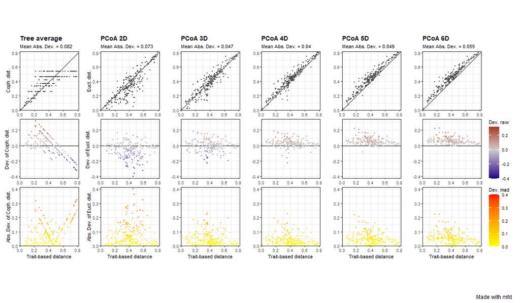

```r
mFD::quality.fspaces.plot(
  fspaces_quality            = fspaces_quality_fruits,
  quality_metric             = "mad",
  fspaces_plot               = c("tree_average", "pcoa_2d", "pcoa_3d",
                                 "pcoa_4d", "pcoa_5d", "pcoa_6d"),
  name_file                  = NULL,
  range_dist                 = NULL,
  range_dev                  = NULL,
  range_qdev                 = NULL,
  gradient_deviation         = c(neg = "darkblue", nul = "grey80", pos = "darkred"),
  gradient_deviation_quality = c(low = "yellow", high = "red"),
  x_lab                      = "Trait-based distance")
```

**NOTE** To know more and better understand how to interpret quality of functional spaces, you should read the [Compute and Interpret Quality of Functional Space](https://cmlmagneville.github.io/mFD/articles/Compute_and_interpret_quality_of_functional_spaces.html) tutorial.

# 5. Test correlation between functional axes and traits

`mFD` allows to test for correlations between traits and functional axes and then illustrate possible correlations. For continuous traits, a linear model is computed and r2 and associated p-value are returned. For non-continuous traits, a Kruskal-Wallis test is computed and eta2 statistic is returned. The function `mFD::traits.faxes.cor()` allows to test and plot correlation and needs the following arguments:

- `sp_tr` is the species x traits data frame
- `sp_faxes_coord` is a matrix of species coordinates taken from the outputs of the `mFD::quality.fspaces()` function **with columns representing axes on which functional space must be computed**. For instance, in this tutorial, we will plot the functional space for 4 and 10 dimensions (*cf.* the two examples below). The whole `sp_faxes_coord` can be retrieved through the output of the `mFD::quality.fspaces()` function:

```r
sp_faxes_coord_fruits <- fspaces_quality_fruits$"details_fspaces"$"sp_pc_coord"
```

- `plot` is a logical value indicating whether correlations should be illustrated or not. If this option is set to `TRUE`, traits-axis relationships are plotted through scatterplot for continuous traits and boxplot for non-continuous traits.

`mFD::traits.faxes.cor` works as follows:

**USAGE**

```r
fruits_tr_faxes <- mFD::traits.faxes.cor(
  sp_tr          = fruits_traits,
  sp_faxes_coord = sp_faxes_coord_fruits[ , c("PC1", "PC2", "PC3", "PC4")],
  plot           = TRUE)
```

We can print only traits with significant effect on position along one of the axis and look at the plots:

```r
# Print traits with significant effect:
fruits_tr_faxes$"tr_faxes_stat"[which(fruits_tr_faxes$"tr_faxes_stat"$"p.value" < 0.05), ]
```

```
##      trait axis           test stat value p.value
## 1     Size  PC1 Kruskal-Wallis eta2 0.308  0.0377
## 3     Size  PC3 Kruskal-Wallis eta2 0.326  0.0325
## 5    Plant  PC1 Kruskal-Wallis eta2 0.471  0.0049
## 6    Plant  PC2 Kruskal-Wallis eta2 0.382  0.0116
## 8    Plant  PC4 Kruskal-Wallis eta2 0.264  0.0360
## 9  Climate  PC1 Kruskal-Wallis eta2 0.731  0.0001
## 13    Seed  PC1 Kruskal-Wallis eta2 0.201  0.0402
## 14    Seed  PC2 Kruskal-Wallis eta2 0.593  0.0005
## 20   Sugar  PC4   Linear Model   r2 0.682  0.0000
```

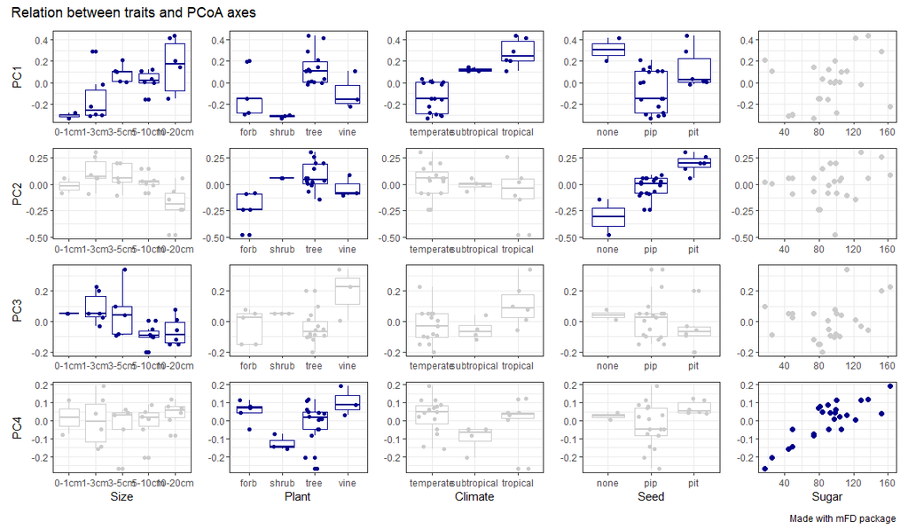

```r
# Return plots:
fruits_tr_faxes$"tr_faxes_plot"
```

# 6. Plot functional space

Once the user has selected the dimensionality of the functional space, `mFD` allows you to plot the given multidimensional functional space and the position of species in all 2-dimensions spaces made by pairs of axes.

The `mFD::funct.space.plot()` function allows to illustrate the position of all species along pairs of space axes.

This function allows to plot with many possibilities to change colors/shapes of each plotted element. Here are listed the main arguments:

- `sp_faxes_coord` is a matrix of species coordinates taken from the outputs of the `mFD::quality.fspaces()` function **with columns representing axes on which functional space must be computed**. For instance, in this tutorial, we will plot the functional space for 4 and 10 dimensions (*cf.* the two examples below). The whole `sp_faxes_coord` can be retrieved through the output of the `mFD::quality.fspaces()` function:

```r
sp_faxes_coord_fruits <- fspaces_quality_fruits$"details_fspaces"$"sp_pc_coord"
```

- `faxes` is a vector containing names of axes to plot. If set to `NULL`, the first four functional axes will be plotted.
- `faxes_nm` is a vector containing labels of `faxes` (following faxes vector rank). If `NULL`, labels follow `faxes` vector names.
- `range_faxes` is a vector to complete if the user wants to set specific limits for functional axes. If `range_faxes = c(NA, NA)`, the range is computed according to the range of values among all axes.
- `plot_ch` is a logical value used to draw or not the 2D convex-hull filled by the global pool of species. Color, fill and opacity of the convex hull can be chosen through other inputs , please refer to the function’s help.
- `plot_sp_nm` is a vector containing species names to plot. If `NULL`, no species names plotted. Name size, color and font can be chosen through other inputs, please refer to the function’s help.
- `plot_vertices` is a logical value used to plot or not vertices with a different shape than other species. **Be careful:** these representations are 2D representations, thus vertices of the convex-hull in the n-multidimensional space can be close to the center of the hull projected in 2D. Color, fill, shape and size of vertices can be chosen through other inputs, please refer to the function’s help.
- `color_bg` is a R color or an hexadecimal color code referring to the color of the background of the plot.
- other inputs are used to chose color, fill, size, and shape of species from the global pool, please refer to the function’s help.
- `check_input` is a recurrent argument in the `mFD` package. It defines whether inputs should be checked before computation or not. Possible error messages will thus be more understandable for the user than R error messages (**Recommendation:** set it as `TRUE`).

**USAGE**

```r
big_plot <- mFD::funct.space.plot(
  sp_faxes_coord  = sp_faxes_coord_fruits[ , c("PC1", "PC2", "PC3", "PC4")],
  faxes           = c("PC1", "PC2", "PC3", "PC4"),
  name_file       = NULL,
  faxes_nm        = NULL,
  range_faxes     = c(NA, NA),
  color_bg        = "grey95",
  color_pool      = "darkgreen",
  fill_pool       = "white",
  shape_pool      = 21,
  size_pool       = 1,
  plot_ch         = TRUE,
  color_ch        = "black",
  fill_ch         = "white",
  alpha_ch        = 0.5,
  plot_vertices   = TRUE,
  color_vert      = "blueviolet",
  fill_vert       = "blueviolet",
  shape_vert      = 23,
  size_vert       = 1,
  plot_sp_nm      = NULL,
  nm_size         = 3,
  nm_color        = "black",
  nm_fontface     = "plain",
  check_input     = TRUE)
```

Here are the plots for the *fruits & baskets* dataset for the **first ten PCoA axis**:

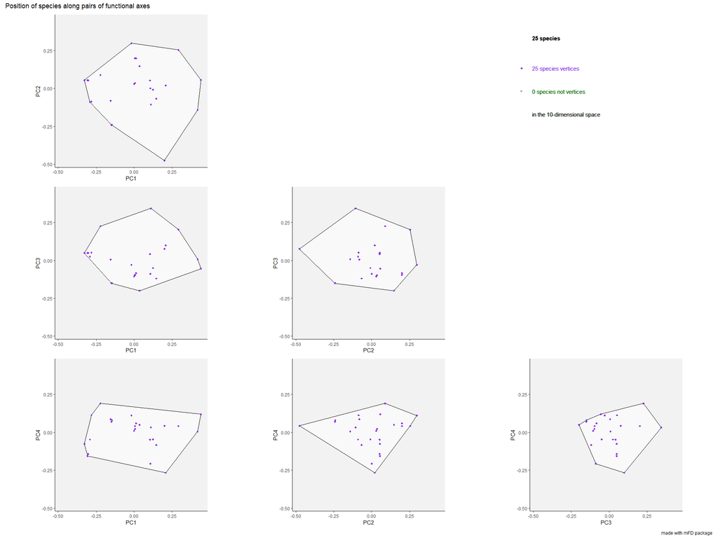

```r
big_plot <- mFD::funct.space.plot(
  sp_faxes_coord  = sp_faxes_coord_fruits,
  faxes           = NULL,
  name_file       = NULL,
  faxes_nm        = NULL,
  range_faxes     = c(NA, NA),
  color_bg        = "grey95",
  color_pool      = "darkgreen",
  fill_pool       = "white",
  shape_pool      = 21,
  size_pool       = 1,
  plot_ch         = TRUE,
  color_ch        = "black",
  fill_ch         = "white",
  alpha_ch        = 0.5,
  plot_vertices   = TRUE,
  color_vert      = "blueviolet",
  fill_vert       = "blueviolet",
  shape_vert      = 23,
  size_vert       = 1,
  plot_sp_nm      = NULL,
  nm_size         = 3,
  nm_color        = "black",
  nm_fontface     = "plain",
  check_input     = TRUE)

# Plot the graph with all pairs of axes:
big_plot$patchwork
```

# 7. Compute functional diversity indices & plot them

## 7.1. Functional alpha diversity indices in a multidimensional space

The `mFD::alpha.fd.multidim()` function allows computing many alpha FD indices:

**USAGE**

```r
alpha_fd_indices_fruits <- mFD::alpha.fd.multidim(
  sp_faxes_coord   = sp_faxes_coord_fruits[ , c("PC1", "PC2", "PC3", "PC4")],
  asb_sp_w         = baskets_fruits_weights,
  ind_vect         = c("fdis", "fmpd", "fnnd", "feve", "fric", "fdiv", "fori",
                       "fspe", "fide"),
  scaling          = TRUE,
  check_input      = TRUE,
  details_returned = TRUE)
```

```
## basket_1 done 10%
```

```
## basket_2 done 20%
```

```
## basket_3 done 30%
```

```
## basket_4 done 40%
```

```
## basket_5 done 50%
```

```
## basket_6 done 60%
```

```
## basket_7 done 70%
```

```
## basket_8 done 80%
```

```
## basket_9 done 90%
```

```
## basket_10 done 100%
```

The arguments and their use are listed below:

- `sp_faxes_coord` is the species coordinates matrix. This dataframe gathers only axis of the functional space you have chosen based on **step 4**.
- `asb_sp_w` is the matrix linking species and assemblages they belong to (summarized in **step 1**).
- `ind_vect` is a vector with names of diversity functional indices to compute. FD indices computed in the `mFD` package can be (explanations based on ([Mouillot *et al.* 2013](https://www.sciencedirect.com/science/article/pii/S0169534712002650)):
  - `FDis` **Functional Dispersion**: the biomass weighted deviation of species traits values from the center of the functional space filled by the assemblage *i.e.* the biomass-weighted mean distance to the biomass-weighted mean trait values of the assemblage.
  - `FRic` **Functional Richness**: the proportion of functional space filled by species of the studied assemblage, *i.e.* the volume inside the convex-hull shaping species. To compute `FRic` the number of species must be at least higher than the number of functional axis + 1.
  - `FDiv` **Functional Divergence**: the proportion of the biomass supported by the species with the most extreme functional traits *i.e.* the ones located close to the edge of the convex-hull filled by the assemblage.
  - `FEve` **Functional Evenness**: the regularity of biomass distribution in the functional space using the Minimum Spanning Tree linking all species present in the assemblage.
  - `FSpe` **Functional Specialization**: the biomass weighted mean distance to the mean position of species from the global pool (present in all assemblages).
  - `FMPD` **Functional Mean Pairwise Distance**: the mean weighted distance between all species pairs.
  - `FNND` **Functional Mean Nearest Neighbour Distance**: the weighted distance to the nearest neighbor within the assemblage.
  - `FIde` **Functional Identity**: the mean traits values for the assemblage. `FIde` is always computed when `FDis` is computed.
  - `FOri` **Functional Originality**: the weighted mean distance to the nearest species from the global species pool.
- `scaling` is a logical value indicating whether indices should be scaled between 0 and 1. If scaling is to be done, this argument must be set to `TRUE`.
- `check_input` is a recurrent argument in the `mFD` package. It defines whether inputs should be checked before computation or not. Possible error messages will thus be more understandable for the user than R error messages (**Recommendation:** set it as `TRUE`).
- `details_returned` is used if the user wants to store information that are used in graphical functions. If the user wants to plot FD indices, then `details_returned` must be set to `TRUE`.

**NB** **Use lowercase letters to enter FD indices names**

The function has two main outputs:

- a **data frame gathering indices values in each assemblage** (for `FIde` values, there are as many columns as there are axes to the studied functional space).

```r
fd_ind_values_fruits <- alpha_fd_indices_fruits$"functional_diversity_indices"
fd_ind_values_fruits
```

```
##           sp_richn      fdis      fmpd      fnnd     feve        fric      fdiv
## basket_1         8 0.4763773 0.6255537 0.4050890 0.565326 0.162830681 0.5514453
## basket_2         8 0.7207823 0.7204459 0.6604092 0.754999 0.162830681 0.8064809
## basket_3         8 0.7416008 0.7274367 0.6748312 0.805534 0.162830681 0.8089535
## basket_4         8 0.2958614 0.3426258 0.2258304 0.759802 0.007880372 0.6080409
## basket_5         8 0.3673992 0.3782650 0.2922436 0.843120 0.007880372 0.7288912
## basket_6         8 0.8001980 0.7838356 0.7295674 0.814829 0.147936148 0.8937934
## basket_7         8 0.8121314 0.8092985 0.7566157 0.827061 0.147936148 0.8989094
## basket_8         8 0.4678159 0.5182996 0.3618776 0.566161 0.036480112 0.7113688
## basket_9         8 0.5577452 0.5566262 0.4563761 0.675735 0.036480112 0.7787237
## basket_10        8 0.5505783 0.5501381 0.4118548 0.660085 0.025774304 0.7741681
##                fori      fspe    fide_PC1     fide_PC2    fide_PC3     fide_PC4
## basket_1  0.2024008 0.4127138 -0.01473662 -0.009461738 -0.05670043 -0.001823969
## basket_2  0.2788762 0.5781232  0.01887361 -0.061601373 -0.04427402  0.021249327
## basket_3  0.3067367 0.5888104  0.04724418 -0.056571400 -0.03631846  0.018045257
## basket_4  0.1766279 0.3106937  0.03994897  0.052581211 -0.08413271 -0.001343112
## basket_5  0.2165945 0.3488358  0.02349573  0.039069220 -0.08187248 -0.010262902
## basket_6  0.6071369 0.7930809  0.24320913 -0.114434642  0.01394977  0.025500282
## basket_7  0.4841824 0.7443406  0.13341179 -0.183609095 -0.01782549  0.021494300
## basket_8  0.2538185 0.6363814 -0.24497368  0.036194656  0.04748935 -0.038827673
## basket_9  0.3126927 0.6309078 -0.21021559  0.029339706  0.05516746 -0.041392184
## basket_10 0.1799705 0.4587432 -0.05375867 -0.005743348 -0.05649324  0.041191011
```

- a **details list** of data frames and sublists gathering information such as coordinates of centroids, distances and identity of the nearest neighbour, distances to the centroid, etc. The user does not have to directly use it but it will be useful if FD indices are then plotted. It can be retrieved through:

```r
details_list_fruits <- alpha_fd_indices_fruits$"details"
```

Then, you can plot functional indices using the `mFD::alpha.multidim.plot()` function as follows:

**USAGE**

```r
plots_alpha <- mFD::alpha.multidim.plot(
  output_alpha_fd_multidim = alpha_fd_indices_fruits,
  plot_asb_nm              = c("basket_1", "basket_5"),
  ind_nm                   = c("fdis", "fide", "fnnd", "feve", "fric",
                               "fdiv", "fori", "fspe"),
  faxes                    = NULL,
  faxes_nm                 = NULL,
  range_faxes              = c(NA, NA),
  color_bg                 = "grey95",
  shape_sp                 = c(pool = 3, asb1 = 21, asb2 = 21),
  size_sp                  = c(pool = 0.7, asb1 = 1, asb2 = 1),
  color_sp                 = c(pool = "grey50", asb1 = "#1F968BFF", asb2 = "#DCE319FF"),
  color_vert               = c(pool = "grey50", asb1 = "#1F968BFF", asb2 = "#DCE319FF"),
  fill_sp                  = c(pool = NA, asb1 = "#1F968BFF", asb2 = "#DCE319FF"),
  fill_vert                = c(pool = NA, asb1 = "#1F968BFF", asb2 = "#DCE319FF"),
  color_ch                 = c(pool = NA, asb1 = "#1F968BFF", asb2 = "#DCE319FF"),
  fill_ch                  = c(pool = "white", asb1 = "#1F968BFF", asb2 = "#DCE319FF"),
  alpha_ch                 = c(pool = 1, asb1 = 0.3, asb2 = 0.3),
  shape_centroid_fdis      = c(asb1 = 22,  asb2 = 24),
  shape_centroid_fdiv      = c(asb1 = 22,  asb2 = 24),
  shape_centroid_fspe      = 23,
  color_centroid_fspe      = "black",
  size_sp_nm               = 3,
  color_sp_nm              = "black",
  plot_sp_nm               = NULL,
  fontface_sp_nm           = "plain",
  save_file                = FALSE,
  check_input              = TRUE)
```

As you can see, this function has a lot of arguments: most of them are graphical arguments allowing the user to chose colors, shapes, sizes, scales, etc. This tutorial only presents main arguments. To learn about the use of graphical arguments, check the function help file. The main arguments of this function are listed below:

- `output_alpha_fd_multidim` is the output of the ``mFD::alpha.fd.multidim()` function.
- `plot_asb_nm` is a vector gathering name(s) of assemblage(s) to plot.
- `ind_vect` is a vector gathering FD indices to plot. Plots are available for `FDis`, `FIde`, `FEve`, `FRic`, `FDiv`, `FOri`, `FSpe`, and `FNND.`
- `faxes` is a vector containing names of axes to plot. You can only plot from two to four axes labels for graphical reasons.
- `faxes_nm` is a vector with axes labels if the user ants different axes labels than `faxes` ones.
- `range_faxes` is a vector with minimum and maximum values for axes. If `range_faxes = c(NA, NA)`, the range is computed according to the range of values among all axes, all axes having thus the same range. To have a fair representation of species positions in all plots, all axes must have the same range.
- `plot_sp_nm` is a vector containing species names to plot. If `NULL`, then no name is plotted.
- size, color, fill, and shape arguments for each component of the graphs *i.e.* species of the global pool, species of the studied assemblage(s), vertices, centroids and segments. If you have to plot two assemblages, then inputs should be formatted as follow: `c(pool = ..., asb1 = ..., asb2 = ...)` for inputs used for global pool and studied assemblages and `c(asb1 = ..., asb2 = ...)` for inputs used for studied assemblages only.
- `check_input` is a recurrent argument in `mFD`. It defines whether inputs should be checked before computation or not. Possible error messages will thus be more understandable for the user than R error messages (**Recommendation:** set it as `TRUE`.

Then, using these arguments, here are the output plots for the **fruits & baskets** dataset:

- `FRic` representation: the colored shapes reflect the convex-hull of the studied assemblages and the white shape reflects the convex-hull of the global pool of species:

[figure not shown]

```r
plots_alpha$"fric"$"patchwork"
```

- `FDiv` representation: the gravity centers of **vertices** (i.e. species with the most extreme functional traits) of each assemblages are plotted as a square and a triangle. Species of each assemblage have different size given their relative weight into the assemblage.

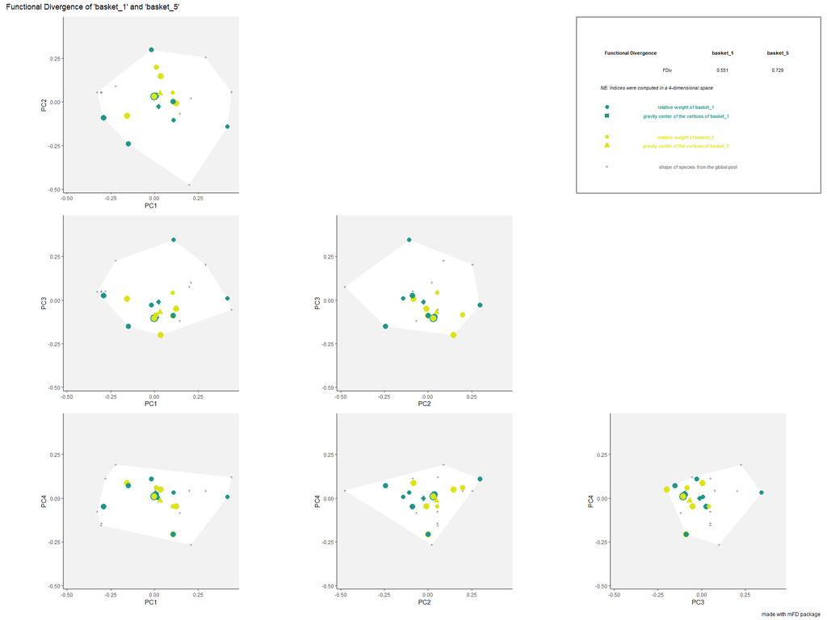

```r
plots_alpha$"fdiv"$"patchwork"
```

[figure not shown]

```r
plots_alpha$"fspe"$"patchwork"
```

- `FDis` representation: colored traits represent distances of each species from a given assemblage to the center of gravity of species of the assemblage (defined by FIde values). The center of gravity of each assemblage is plotted using a square and a triangle. Species of each assemblage havedifferent size given their relative weight into the assemblage.

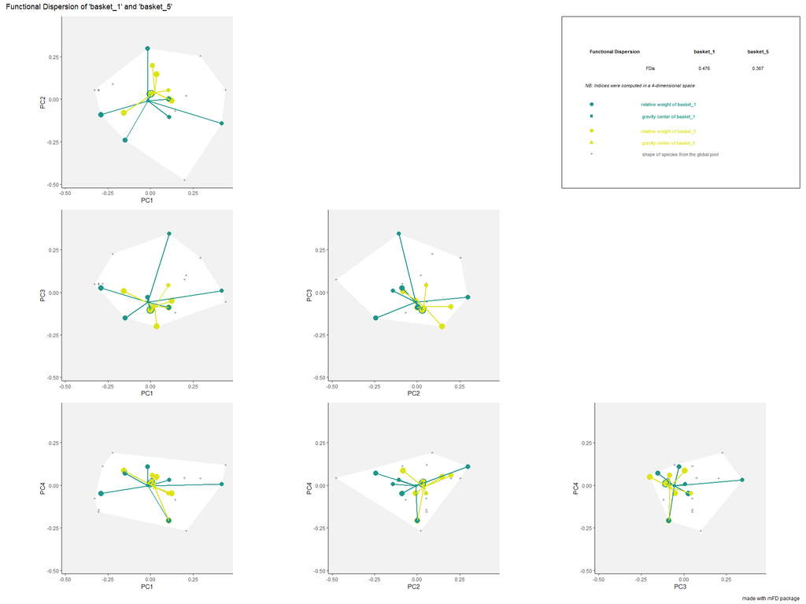

```r
plots_alpha$"fdis"$"patchwork"
```

- `FIde` representation:colored lines refer to the weighted average position of species of each assemblage along each axis. Species of each assemblage have different size given their relative weight into the assemblage.

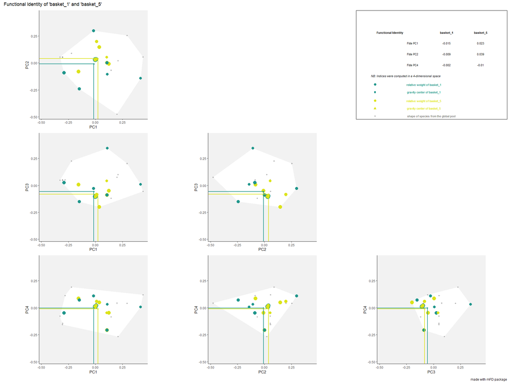

```r
plots_alpha$"fide"$"patchwork"
```

- `FEve` representation: colored traits represent the Minimum Spanning Tree linking species of each assemblage. Species of each assemblage have different size given their relative weight into the assemblage.

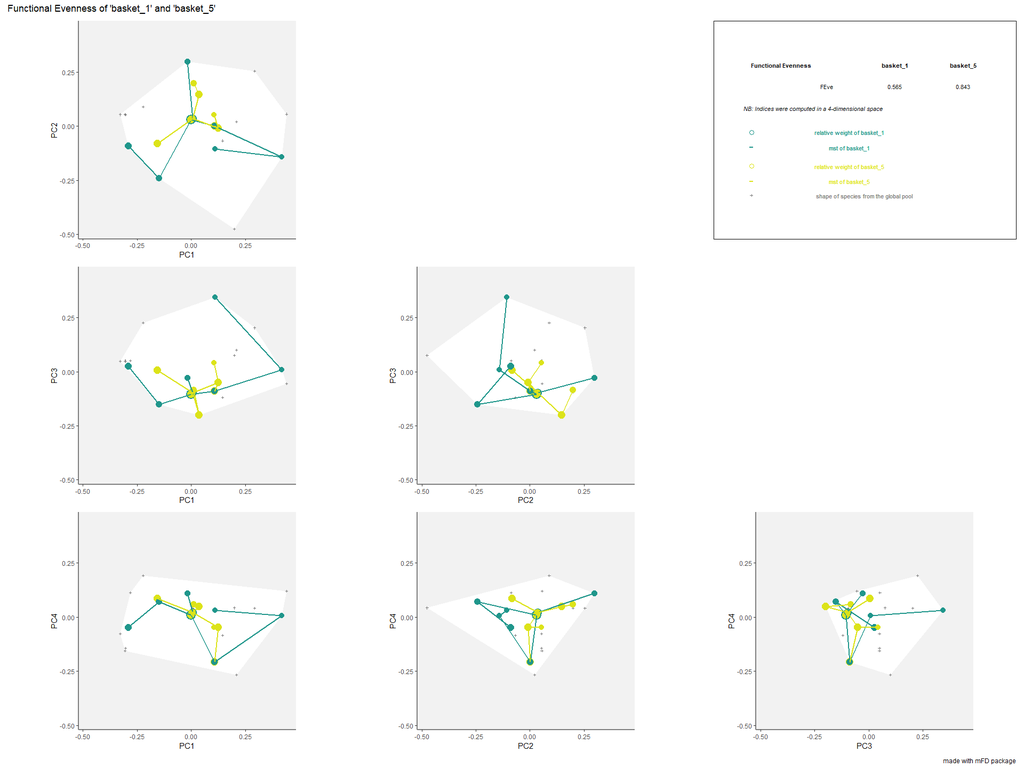

```r
plots_alpha$"feve"$"patchwork"
```

- `FOri` representation: colored arrows represent the distances of each species from each assemblage to the nearest species in the global species pool. Species of each assemblage have different size given their relative weight into the assemblage.

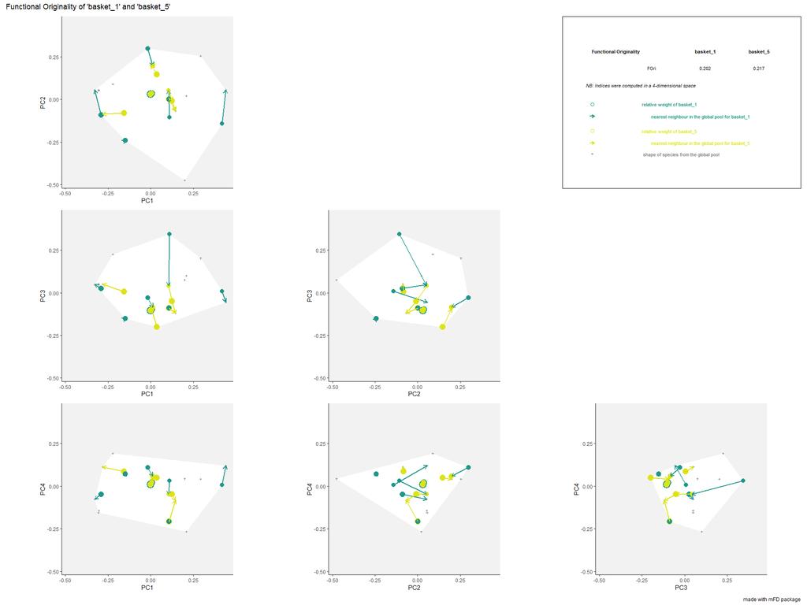

```r
plots_alpha$"fori"$"patchwork"
```

- `FNND` representation: colored arrows represent the distances of each species from each assemblage to the nearest species in the studied assemblage. Species of each assemblage have different size given their relative weight into the assemblage.

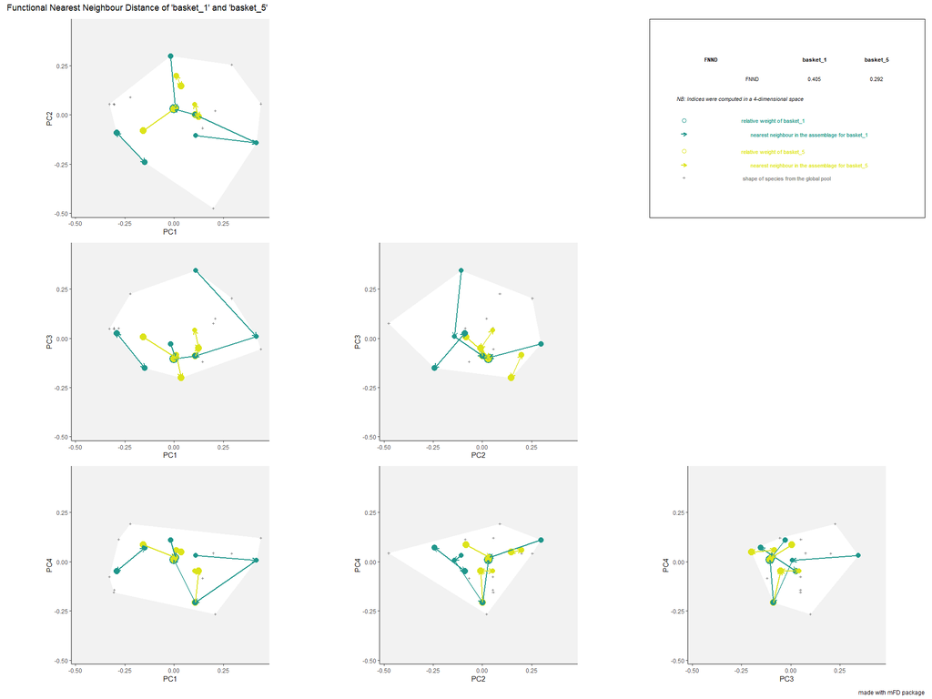

```r
plots_alpha$"fnnd"$"patchwork"
```

## 7.2. Functional beta diversity indices based on multidimensional space

**NOTE:** Some Mac OS X 10.15 may encounter some issues with the beta_*() functions.

`mFD` package allows you to compute beta diversity indices for each assemblage pairs following [Villeger *et al.* 2013](https://onlinelibrary.wiley.com/doi/full/10.1111/geb.12021). For that we will use the `mFD::beta.fd.multidim()` function.

**NOTE** This function can compute two families of functional beta diversity indices, either **Jaccard** or **Sorensen**.

In this example, we will use Jaccard index. For each assemblages pair, the dissimilarity index is decomposed into two additive components: **turnover** and **nestedness-resultant**. **NB** The **turnover** component is the highest if there is no shared traits combination between the two assemblages. The **nestedness** component is the highest if one assemblage hosts a small subset of the functional strategies present in the other.

The `mFD::beta.fd.multidim()` function has the main following arguments:

**USAGE**

```r
beta_fd_indices_fruits <- mFD::beta.fd.multidim(
      sp_faxes_coord   = sp_faxes_coord_fruits[ , c("PC1", "PC2", "PC3", "PC4")],
      asb_sp_occ       = asb_sp_fruits_occ,
      check_input      = TRUE,
      beta_family      = c("Jaccard"),
      details_returned = TRUE)
```

- `sp_faxes_coord` is the species coordinates matrix. This dataframe gathers **only** axis of the functional space you have chosen based on **step 4**.
- `asb_sp_occ` is the matrix of occurrence (coded as 0/1) of species assemblages (summarized in **step 1**).
- `check_input` is a recurrent argument in the `mFD` package. It defines whether inputs should be checked before computation or not. Possible error messages will thus be more understandable for the user than R error messages (**Recommendation:** set it as `TRUE`.
- `beta_family` a character string for the type of beta-diversity index to compute, it can either be `Jaccard` or `Sorensen`.
- `details_returned` is a logical value indicating whether details of outputs must be stored. It should be stored if you plan to use the graphical function to illustrate beta diversity indices thereafter.
- There are also other arguments for parallelisation options. Check the function help file for more explanation.

The function returns a list containing:

- a dist object with beta indices values for each pair of assemblages
- a list containing details such as inputs, vertices of the global pool and of each assemblage and FRic values for each assemblage
- a vector containing the `FRic` value for each assemblage retrieved through the `details_beta` list
- a list of vectors containing names of species being vertices of the convex hull for each assemblage retrieved through the `details_beta` list

Then, the package allows the user to illustrate functional beta-diversity indices for a pair of assemblages in a multidimensional space using the `mFD::beta.multidim.plot()` function. The output of this function is a figure showing the overlap between convex hulls shaping each of the two species assemblages.

The plotting function has a large number of arguments, allowing the user to chose graphical options. Arguments are listed below:

**USAGE**

```r
beta_plot_fruits <- mFD::beta.multidim.plot(
  output_beta_fd_multidim = beta_fd_indices_fruits,
  plot_asb_nm             = c("basket_1", "basket_4"),
  beta_family             = c("Jaccard"),
  plot_sp_nm              = c("apple", "lemon", "pear"),
  faxes                   = paste0("PC", 1:4),
  name_file               = NULL,
  faxes_nm                = NULL,
  range_faxes             = c(NA, NA),
  color_bg                = "grey95",
  shape_sp                = c("pool" = 3.0, asb1 = 22, asb2 = 21),
  size_sp                 = c("pool" = 0.8, asb1 =  1, asb2 =  1),
  color_sp                = c("pool" = "grey50", asb1 = "blue", asb2 = "red"),
  fill_sp                 = c("pool" = NA, asb1 = "white", asb2 = "white"),
  fill_vert               = c("pool" = NA, asb1 = "blue", asb2 = "red"),
  color_ch                = c("pool" = NA, asb1 = "blue", asb2 = "red"),
  fill_ch                 = c("pool" = "white", asb1 = "blue", asb2 = "red"),
  alpha_ch                = c("pool" = 1, asb1 = 0.3, asb2 = 0.3),
  nm_size                 = 3,
  nm_color                = "black",
  nm_fontface             = "plain",
  check_input             = TRUE)
```

Then, the function returns each graph for each functional axes combination and also a multipanel plot with all combinations of axes and the graph caption.

# References

- Johnson *et al.* (2020) Handling missing values in trait data. *Global Ecology and Biogeography*, **30**, 51-62.
- Maire *et al.* (2015) How many dimensions are needed to accurately assess functional diversity? A pragmatic approach for assessing the quality of functional spaces. *Global Ecology and Biogeography*, **24**, 728-740.
- Mouillot *et al.* (2013) A functional approach reveals community responses to disturbances. *Trends in Ecology and Evolution*, **28**, 167-177.
- Mouillot *et al.* (2014) Functional over-redundancy and high functional vulnerability in global fish faunas on tropical reefs. *PNAS*, **38**, 13757-13762.